# Week 10 R Workshop

Elmer V Villanueva

November 20, 2019

In this session, we will learn about general procedures used to compare the means of two groups.

# Set your working directory

```r
setwd("D:/git/DPH101-xjtlu/Y3/week11_lec_11.18")
```

# Download the data files from ICE onto your working directory

You will need to download and unzip the data file package from ICE. It contains four data files in CSV format.

# Independent-samples Student’s t-test with pooled variance

Ward and Quinn (1988) investigated differences in the fecundity (as measured by egg production) of a predatory intertidal gastropod (*Lepsiella vinosa*) in two different intertidal zones (mussel zone and the higher littorinid zone). We wish to test the null hypothesis that the population mean egg production is the same for both littorinid and mussel zones.

1. Import the data.

```r
ward <- read.csv("ward.csv")
str(ward)
```

```
## 'data.frame':    79 obs. of  2 variables:
##  $ ZONE: Factor w/ 2 levels "Littor","Mussel": 2 2 2 2 2 2 2 2 2 2 ...
##  $ EGGS: int  11 8 18 10 9 13 15 12 9 15 ...
```

```r
head(ward)
```

```
##     ZONE EGGS
## 1 Mussel   11
## 2 Mussel    8
## 3 Mussel   18
## 4 Mussel   10
## 5 Mussel    9
## 6 Mussel   13
```

2. Assess assumption of normality and homogeneity of variance.

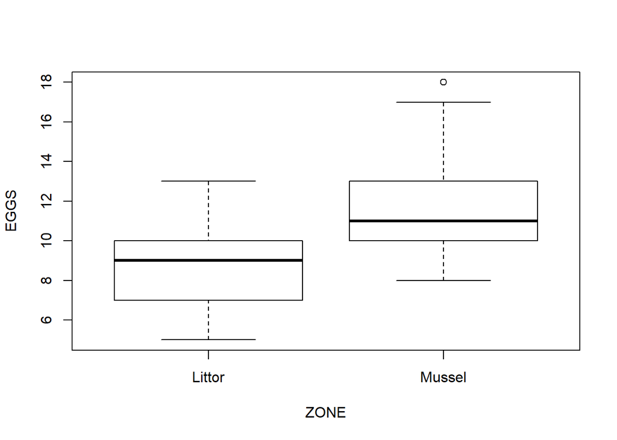

```r
boxplot(EGGS ~ ZONE, data = ward)
```

```r
with(ward, rbind(MEAN<-tapply(EGGS,ZONE,mean),
                 VAR<-tapply(EGGS,ZONE,var)))
```

```
##        Littor    Mussel
## [1,] 8.702703 11.357143
## [2,] 4.103604  5.357143
```

**Conclusion.** There was no evidence of non-normality (boxplots not grossly asymmetrical) or unequal variance (boxplots very similar size and variances very similar). Hence, the simple, studentized (pooled variances) t-test is likely to be reliable.

3. Perform an independent-samples t-test with pooled variance.

```r
t.test(EGGS ~ ZONE, data = ward,
       var.equal = T)
```

```
##
##  Two Sample t-test
##
## data:  EGGS by ZONE
## t = -5.3899, df = 77, p-value = 7.457e-07
## alternative hypothesis: true difference in means is not equal to 0
## 95 percent confidence interval:
##  -3.63511 -1.67377
## sample estimates:
## mean in group Littor mean in group Mussel
##             8.702703            11.357143
```

**Conclusions.** Reject the null hypothesis. Egg production by predatory gastropods was significantly greater (t<sub>77</sub> = -5.39, P < 0.001) in mussel zones than littorinid zones on rocky intertidal shores.

# Independent-samples Student’s t-test with Satterthwaite’s adjustment for unpooled variance

Furness and Bryant (1996) measured the metabolic rates of eight male and six female breeding northern fulmars and were interesting in testing the null hypothesis that there was no difference in metabolic rate between the sexes.

1. Import the data.

```r
furness <- read.csv("furness.csv")
str(furness)
```

```
## 'data.frame':    14 obs. of  3 variables:
##  $ SEX     : Factor w/ 2 levels "Female      ",..: 2 1 2 2 2 1 1 1 1 2 ...
##  $ METRATE : num  2950 1956 2309 2136 1946 ...
##  $ BODYMASS: int  875 635 765 780 790 635 668 640 645 788 ...
```

```r
head(furness)
```

```
##            SEX METRATE BODYMASS
## 1 Male          2950.0      875
## 2 Female        1956.1      635
## 3 Male          2308.7      765
## 4 Male          2135.6      780
## 5 Male          1945.6      790
## 6 Female        1490.5      635
```

2. Assess the assumptions of normality and homogeneity of variance.

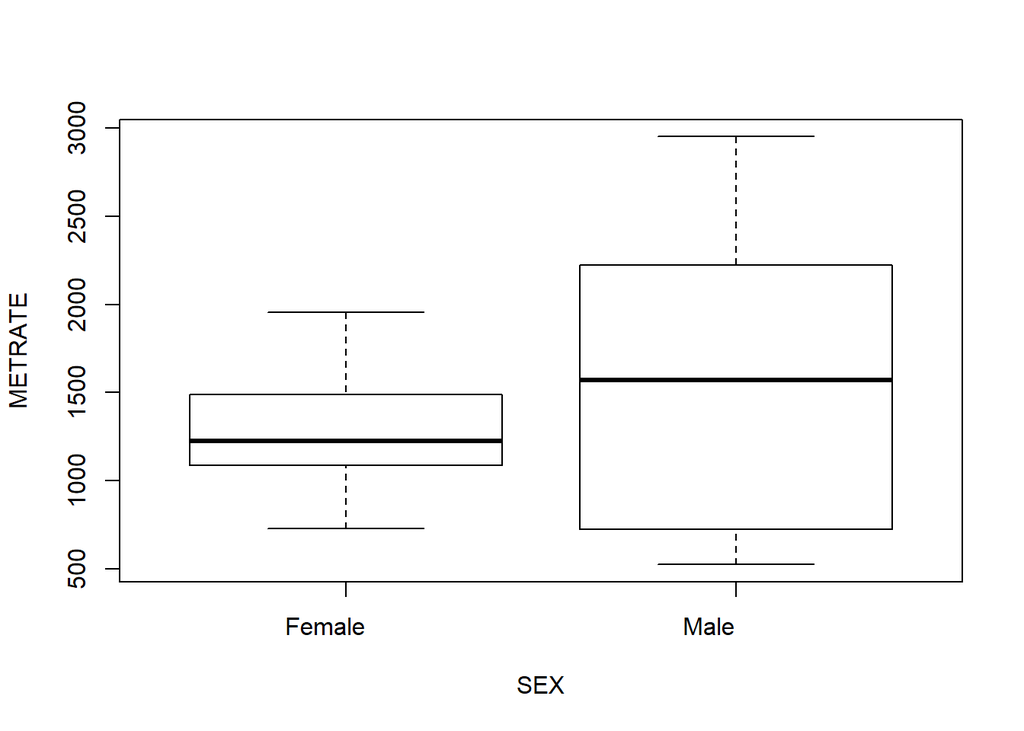

```r
boxplot(METRATE ~ SEX, data = furness)
```

```r
with(furness, rbind(MEAN = tapply(METRATE, SEX, mean),
                    VAR = tapply(METRATE, SEX, var)))
```

```
##      Female       Male
## MEAN     1285.517     1563.775
## VAR    177209.418   799902.525
```

**Conclusions.** Whilst there is no evidence of non-normality (boxplots not grossly asymmetrical), variances are a little unequal (although perhaps not grossly unequal - one of the boxplots is not more than three times smaller than the other). Hence, a separate variances t-test is more appropriate than a pooled variances t-test.

3. Perform an independent-samples t-test with Satterthwaite’s adjustment.

```r
t.test(METRATE ~ SEX, data = furness,
       var.equal = FALSE)
```

```
##
##  Welch Two Sample t-test
##
## data:  METRATE by SEX
## t = -0.77317, df = 10.468, p-value = 0.4565
## alternative hypothesis: true difference in means is not equal to 0
## 95 percent confidence interval:
##  -1075.3208   518.8042
## sample estimates:
## mean in group Female       mean in group Male
##                   1285.517                   1563.775
```

**Conclusions.** Do not reject the null hypothesis. Metabolic rate of male breeding northern fulmars was not found to differ significantly (t = -0.773, df = 10.468, P = 0.457) from that of females.

# Paired Student’s t-test

To investigate the effects of lighting conditions on the orb-spinning spider webs Elgar et al. (1996) measured the horizontal (width) and vertical (height) dimensions of the webs made by 17 spiders under light and dim conditions. Accepting that the webs of individual spiders vary considerably, Elgar et al. (1996) employed a paired design in which each individual spider effectively acts as its own control.

1. Import the data.

```r
elgar <- read.csv("elgar.csv")
str(elgar)
```

```
## 'data.frame':    17 obs. of  5 variables:
##  $ PAIR    : Factor w/ 17 levels "A","B","D+","E",..: 9 10 11 12 13 14 15 1 2 3 ...
##  $ VERTDIM : int  300 240 250 220 160 170 300 180 200 80 ...
##  $ HORIZDIM: int  295 260 280 250 160 150 290 120 210 120 ...
##  $ VERTLIGH: int  80 120 170 90 150 110 260 240 190 120 ...
##  $ HORIZLIG: int  60 140 160 120 180 90 120 220 210 150 ...
```

```r
head(elgar)
```

```
##   PAIR VERTDIM HORIZDIM VERTLIGH HORIZLIG
## 1    K     300      295       80       60
## 2    M     240      260      120      140
## 3    N     250      280      170      160
## 4    O     220      250       90      120
## 5    P     160      160      150      180
## 6    R     170      150      110       90
```

2. Assess the assumption of norrmality

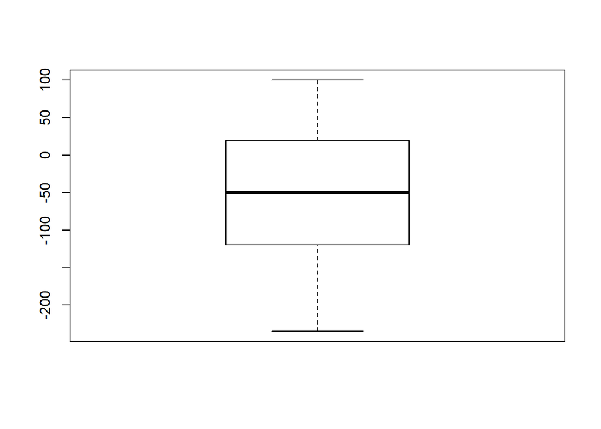

```r
with(elgar, boxplot(HORIZLIG - HORIZDIM))
```

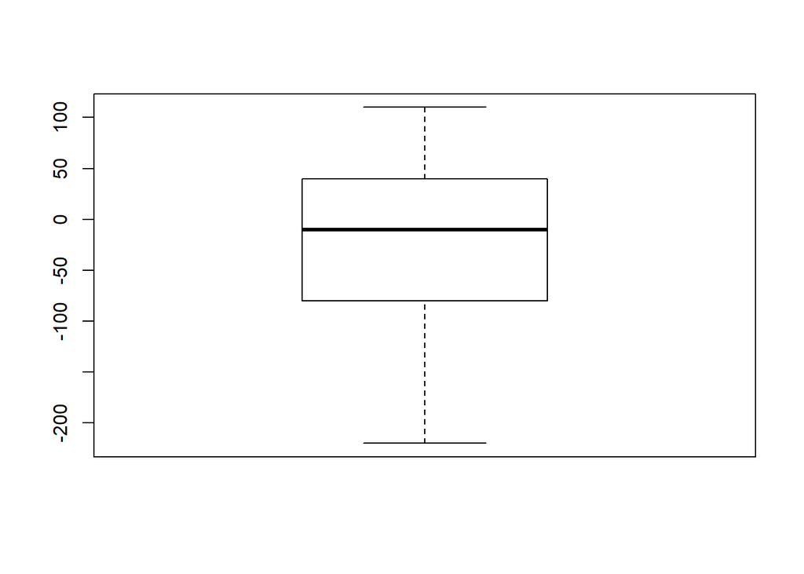

```r
with(elgar, boxplot(VERTLIGH - + VERTDIM))
```

**Conclusions.** There is no evidence of non-normality for either the difference in widths or heights of webs under light and dim ambient conditions. Therefore paired t-tests are likely to be reliable tests of the hypotheses that the mean web dimensional differences are equal to zero.

3. Perform two separate paired t-tests to test the test the respective null hypotheses.

3.1. No effect of lighting on web width

```r
with(elgar, t.test(HORIZLIG, HORIZDIM, paired = T))
```

```
##
##  Paired t-test
##
## data:  HORIZLIG and HORIZDIM
## t = -2.1482, df = 16, p-value = 0.04735
## alternative hypothesis: true difference in means is not equal to 0
## 95 percent confidence interval:
##  -91.7443687  -0.6085725
## sample estimates:
## mean of the differences
##               -46.17647
```

3.2. No effect of lighting on web height

```r
with(elgar, t.test(VERTLIGH, VERTDIM, paired = T))
```

```
##
##  Paired t-test
##
## data:  VERTLIGH and VERTDIM
## t = -0.96545, df = 16, p-value = 0.3487
## alternative hypothesis: true difference in means is not equal to 0
## 95 percent confidence interval:
##  -65.79532  24.61885
## sample estimates:
## mean of the differences
##               -20.58824
```

**Conclusions.** Orb-spinning spider webs were found to be significantly wider (t = 2.148, df = 16, P = 0.047) under dim lighting conditions than light conditions, yet were not found to differ (t = 0.965, df = 16, P = 0.349) in height.

# Non-parametric Mann-Whitney U (also known as Wilcoxon rank sum) test

Sokal and Rohlf (1997) presented a dataset comprising the lengths of cheliceral bases (in ?m) from two samples of chigger (*Trombicula lipovskyi*) nymphs.

1. Import the data.

```r
nymphs <- read.csv("nymphs.csv")
str(nymphs)
```

```
## 'data.frame':    26 obs. of  2 variables:
##  $ SAMPLE: Factor w/ 2 levels "Sample A","Sample B": 1 1 1 1 1 1 1 1 1 1 ...
##  $ LENGTH: int  104 109 112 114 116 118 118 119 121 123 ...
```

```r
head(nymphs)
```

```
##     SAMPLE LENGTH
## 1 Sample A    104
## 2 Sample A    109
## 3 Sample A    112
## 4 Sample A    114
## 5 Sample A    116
## 6 Sample A    118
```

2. Assess the assumptions of normality and homogeneity of variance.

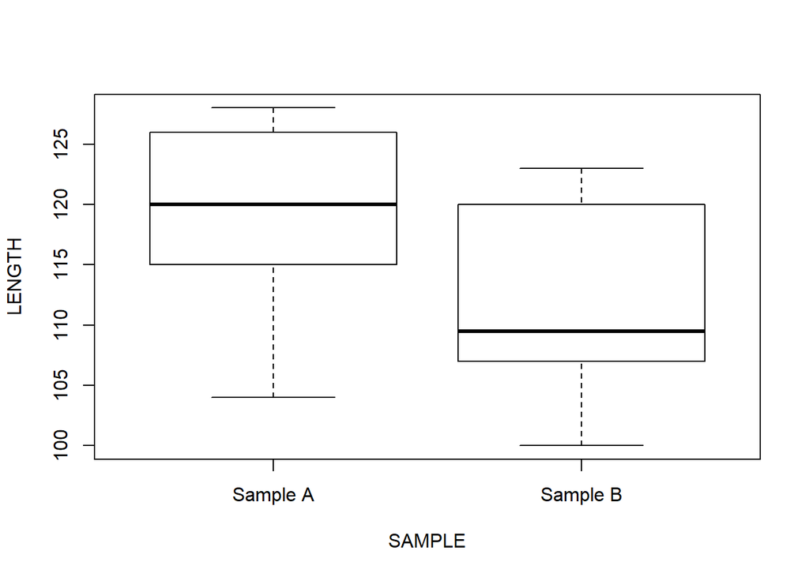

```r
boxplot(LENGTH ~ SAMPLE, data = nymphs)
```

```r
with(nymphs, rbind(MEAN = tapply(LENGTH, SAMPLE, mean),
                   VAR = tapply(LENGTH, SAMPLE, var)))
```

```
##       Sample A  Sample B
## MEAN 119.68750 111.80000
## VAR   53.29583  60.17778
```

**Conclusions.** Whilst there is no evidence of unequal variance, there is some (possible) evidence of non-normality (boxplots slightly asymmetrical).

3. Perform a Mann-Whitney U test (otehrwise known as the Wilcoxon rank sum test) to investigate the null hypothesis that the mean length of cheliceral bases is the same for the two samples of nymphs of chigger (*Trombicular lipovskyi*).

```r
wilcox.test(LENGTH ~ SAMPLE, data = nymphs)
```

```
##
##  Wilcoxon rank sum test with continuity correction
##
## data:  LENGTH by SAMPLE
## W = 123.5, p-value = 0.0232
## alternative hypothesis: true location shift is not equal to 0
```

**Conclusions.** Reject the null hypothesis. The length of the cheliceral base is significantly longer in nymphs from sample 1 (W = 123.5, df = 24, P = 0.023) than those from sample 2.